# 13_DNO_textbook

The relative error over the test shapes, by `relative_error` of Lab 3 with each model's two networks, is printed for both models at six times up to $t = 0.5$, of which the first three lie inside the record; the same test shape is drawn at three times beyond the record, with the exact solution as a solid line, the data-driven prediction dashed and the physics-informed prediction dotted; and the two errors are drawn as curves over $(0, 0.5]$, with the end of the record marked.

```
   t      data only   data and physics
 0.05      0.0573        0.1106
 0.15      0.0919        0.1571
 0.25      0.1183        0.1504
 0.30      0.7378        0.2106    (beyond the record)
 0.40      2.1476        0.2271    (beyond the record)
 0.50      2.4856        0.3826    (beyond the record)
```

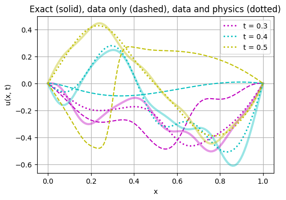

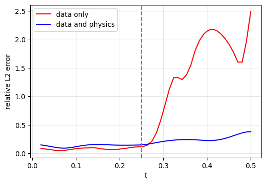

```python
print('   t      data only   data and physics')
for t in [0.05, 0.15, 0.25, 0.3, 0.4, 0.5]:
    print('%5.2f      %.4f        %.4f%s' % (t, relative_error(branch_data, trunk_data, t), relative_error(branch_pi, trunk_pi, t),
                                             '' if t <= 0.25 else '    (beyond the record)'))

plt.figure(figsize = (6, 4))
for t, c in zip([0.3, 0.4, 0.5], ['m', 'c', 'y']):
    plt.plot(x, solution(coef_test[j], t), c, alpha = 0.4, linewidth = 3)
    plt.plot(x, predict(branch_data, trunk_data, t)[j], c + '--')
    plt.plot(x, predict(branch_pi, trunk_pi, t)[j], c + ':', linewidth = 2, label = 't = %g' % t)
plt.xlabel('x')
plt.ylabel('u(x, t)')
plt.title('Exact (solid), data only (dashed), data and physics (dotted)')
plt.legend()
plt.grid(True)
plt.show()

t_curve = np.linspace(0.02, T_end, 50)
plt.figure(figsize = (6, 4))
plt.plot(t_curve, [relative_error(branch_data, trunk_data, t) for t in t_curve], 'r', label = 'data only')
plt.plot(t_curve, [relative_error(branch_pi, trunk_pi, t) for t in t_curve], 'b', label = 'data and physics')
plt.axvline(0.25, color = 'gray', linestyle = '--')
plt.xlabel('t')
plt.ylabel('relative L2 error')
plt.legend()
plt.grid(True, alpha = 0.3)
plt.show()
```

**Beyond the Record, Continuously**

The physics-informed prediction and the exact solution for the same test shape, through sixty times up to $t = 0.5$. The title reports the time and says whether it lies inside the record or beyond it; the second half of the animation is the quarter the data never saw.

```python
frames = np.linspace(0.001, T_end, 60)
exact = np.stack([solution(coef_test[j], t) for t in frames])                   # (60, 128)
pred_data = np.stack([predict(branch_data, trunk_data, t)[j] for t in frames])   # (60, 128)
pred_pi = np.stack([predict(branch_pi, trunk_pi, t)[j] for t in frames])         # (60, 128)

fig = plt.figure(figsize = (6, 4))
line_exact = plt.plot(x, exact[0], 'k', alpha = 0.4, linewidth = 3, label = 'Exact')[0]
line_data = plt.plot(x, pred_data[0], 'r--', label = 'Data only')[0]
line_pi = plt.plot(x, pred_pi[0], 'b:', linewidth = 2, label = 'Data and physics')[0]
title = plt.title('t = 0')
plt.xlabel('x')
plt.ylabel('u(x, t)')
plt.ylim(exact.min() - 0.1, exact.max() + 0.1)
plt.legend(loc = 'upper right')
plt.grid(True)
plt.close()

def update(i):
    line_exact.set_ydata(exact[i])
    line_data.set_ydata(pred_data[i])
    line_pi.set_ydata(pred_pi[i])
    title.set_text('t = %.3f  (%s)' % (frames[i], 'inside the record' if frames[i] <= 0.25 else 'beyond the record'))
    return line_exact, line_data, line_pi, title

anim = animation.FuncAnimation(fig, update, frames = len(frames), interval = 100)
HTML(anim.to_jshtml())
```

[figure not shown]

**What the Experiment Shows**

Inside the record the two models are close, and the data-driven one is slightly better, since it has nothing else to satisfy. Beyond the record they part company at once. The data-driven model has nothing to go on, and its error soon exceeds that of predicting nothing at all; the physics-informed model carries the solution forward, following the travelling halves and their reflections although none of these were in its data, with an error that grows only slowly with the distance from the record. The animation shows the same through the whole interval. The growth is the mark of an equation enforced only approximately: a small residual integrated over a longer time gives a larger error, as a time-stepping scheme accumulates its truncation error step by step, and a longer record or a smaller residual would push the usable horizon further.

This is the division of labour that makes the hybrid worth having. The data fix the coefficients of the operator, which the equation alone cannot do, because every combination of the modes $\cos(k\pi t)\sin(k\pi x)$ satisfies the wave equation, the fixed ends and the zero initial velocity whatever its coefficients; the equation then fixes how those coefficients evolve, which the data alone cannot do beyond the last time they were recorded. A physics term is worth its cost where the data leave gaps, in time, in space, or in the number of solved cases, and the equation has to fill them; where the data are dense the equation can only repeat what they already say.

The construction is the one the next notebook uses throughout. Whether the physics term supplements the data, as here and in the cylinder flow, or replaces it altogether, as for the thin plate, the residual is evaluated pair by pair through the trunk coordinates, exactly as a PINN evaluates it through its input, and the branch and trunk are trained on it with the same optimizer as before.

# Summary

**Key takeaways**

- A PINN approximates one solution; an operator network approximates the solution operator $\mathcal{G}: u \mapsto s$ over a family of inputs, and is trained once. The offline cost is a set of solved (or physics-constrained) instances, the online saving is that every new condition is a forward pass; whether the trade pays depends on how many queries will be issued.
- The DeepONet evaluates $\mathcal{G}(u)(y) \approx \sum_{k=1}^p b_k(u)\, t_k(y)$: the branch network maps the input function, sampled at $m$ fixed sensors, to $p$ coefficients, and the trunk network maps the output coordinate $y$ to $p$ basis functions. The sensors are frozen into the branch's first layer; the output is a function of $y$ and can be queried anywhere at any resolution. The universal approximation theorem for operators guarantees existence, not size, trainability or extrapolation.
- Reading the operator as basis and coefficients predicts the training runs. Conduction, $T = T_{BC}\,y$, has rank one; the cantilever under loads drawn from a seven-term family has rank seven; both fit in seconds with $p = 16$, and both tests are interpolation inside the training family and say nothing about loads of a new shape.
- In PyTorch the whole model is two `nn.Sequential` networks and one product: `branch(U) @ trunk(Y).T` gives every condition at every point when the data set is small enough to use whole, and `torch.sum(b*t, dim = 1)` gives one value per condition-point pair when each pair has to be handled on its own, as it must when the physics residual is differentiated through the trunk; the training loop is the ordinary supervised one.
- A time-dependent problem needs nothing new: the transient-conduction lab gives the trunk the pair $(x, t)$, keeps the matrix form of the beam lab, and after one training run answers at times it never saw.
- On the vibrating string the solution oscillates instead of decaying, and a trunk that reads $t$ as a plain coordinate cannot follow it, the spectral bias of a network along the time axis; given $\cos(m\pi t)$ and $\sin(m\pi t)$ instead, with nothing else changed from the cooling rod, the same matrix-form training follows the motion through the whole interval.
- **A physics term carries the solution where the data do not reach.** On the string the wave-equation residual is evaluated pair by pair, one initial shape with one random point, by `torch.autograd.grad` through the trunk coordinates, and added to the data term. Given a record that stops early, the data-driven operator fails beyond it, while the physics-informed one follows the motion on: the data fix the coefficients, the equation fixes how they evolve. This hybrid, data where it exists and the equation everywhere else, is the construction of the next notebook.
- A physics-informed DeepONet, developed in the next notebook, keeps the architecture and replaces the data term with the PDE residual at collocation points plus boundary terms, each obtained by `torch.autograd.grad` through the trunk coordinate exactly as in a PINN, so that no solved examples are needed; the price is a long, delicately balanced optimisation, and the input family still bounds what the operator can be trusted on.

**Looking ahead.** Deep Operator Networks: Labs carries the DeepONet into seven laboratories, among them the cooling plate whose decaying solution hides the late times from the loss, and ending with a physics-informed thin plate and a hybrid cylinder flow; Fourier Neural Operator learns the same kind of operator by a different route, parameterising the map in frequency space so that it is resolution-independent by construction; Embedding Prior Knowledge into Neural Networks steps back to survey every way, from the loss to the architecture to the data, in which what is already known can be built into a network.